# Next Word Prediction

Wanjie Feng

2024-04-15

# Project Overview

Around the world, people are spending an increasing amount of time on their mobile devices for email, social networking, banking and a whole range of other activities. But typing on mobile devices can be a serious pain. SwiftKey, our corporate partner in this capstone, builds a smart keyboard that makes it easier for people to type on their mobile devices. One cornerstone of their smart keyboard is predictive text models. When someone types:

*I went to the*

the keyboard presents three options for what the next word might be. For example, the three words might be *gym, store, restaurant*.

In this capstone, the text data logged from News, Twitter, and Blogs are analyzed and processed. These data are used to build a model to predict the next word when giving a phrase.

# Outline of the Project

- Data download and read in
- Exploratory Data Analysis
- Build Katz backoff model
- Predict Next Words
- Shiny App

# Exploratory Data Analysis

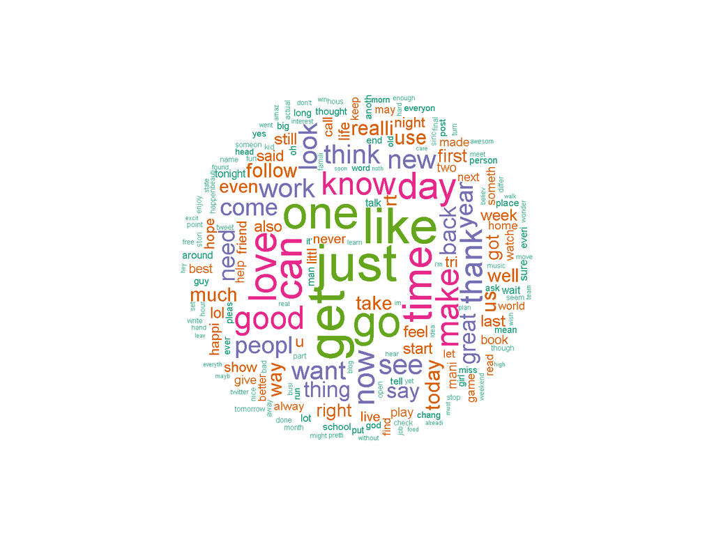

# Katz Backoff Model

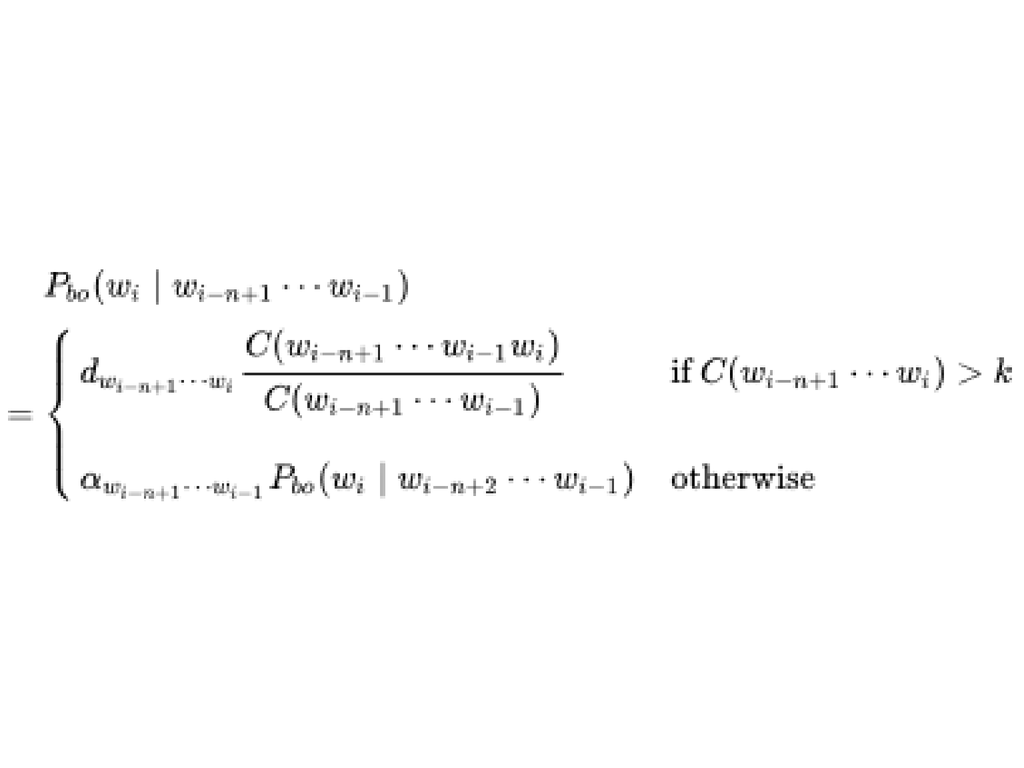

# Predict Next Word and Shiny App

- The R markdown and Shiny App files can be found at https://github.com/Aaron2014/JHU_Capstone_Project
- The Shiny App can be accessed at https://es0for-aaron-fong.shinyapps.io/predict_word/